# Machine Learning Course Project

Frank Sauvage

Friday, October 09, 2015

Objective: predict the manner in which user did a barbell lift exercise. The report describs how the model was built, the use of cross validation, the expected out of sample error and explain the choices made.

Setting of the working directory, loading of required packages and loading and checking of the data sets

```r
options(warn=-1)
setwd("D:/Statsphere/Formation_DataScience/Course 8 Machine Learning/Course Project")
library(caret)
library(timeSeries)
library(e1071)
dataCP <- read.csv("pml-training.csv") #Course Project data
data.toPredict <- read.csv("pml-testing.csv") #the Course Project data to predict for the submission part
head(dataCP)[,2:8]
```

```
##   user_name raw_timestamp_part_1 raw_timestamp_part_2   cvtd_timestamp
## 1  carlitos           1323084231               788290 05/12/2011 11:23
## 2  carlitos           1323084231               808298 05/12/2011 11:23
## 3  carlitos           1323084231               820366 05/12/2011 11:23
## 4  carlitos           1323084232               120339 05/12/2011 11:23
## 5  carlitos           1323084232               196328 05/12/2011 11:23
## 6  carlitos           1323084232               304277 05/12/2011 11:23
##   new_window num_window roll_belt
## 1         no         11      1.41
## 2         no         11      1.41
## 3         no         11      1.42
## 4         no         12      1.48
## 5         no         12      1.48
## 6         no         12      1.45
```

```r
head(data.toPredict)[,2:8]
```

```
##   user_name raw_timestamp_part_1 raw_timestamp_part_2   cvtd_timestamp
## 1     pedro           1323095002               868349 05/12/2011 14:23
## 2    jeremy           1322673067               778725 30/11/2011 17:11
## 3    jeremy           1322673075               342967 30/11/2011 17:11
## 4    adelmo           1322832789               560311 02/12/2011 13:33
## 5    eurico           1322489635               814776 28/11/2011 14:13
## 6    jeremy           1322673149               510661 30/11/2011 17:12
##   new_window num_window roll_belt
## 1         no         74    123.00
## 2         no        431      1.02
## 3         no        439      0.87
## 4         no        194    125.00
## 5         no        235      1.35
## 6         no        504     -5.92
```

```r
dim(dataCP)
```

```
## [1] 19622   160
```

```r
dim(data.toPredict)
```

```
## [1]  20 160
```

```r
names(dataCP)[1:10]
```

```
##  [1] "X"                    "user_name"            "raw_timestamp_part_1"
##  [4] "raw_timestamp_part_2" "cvtd_timestamp"       "new_window"
##  [7] "num_window"           "roll_belt"            "pitch_belt"
## [10] "yaw_belt"
```

*MACHINE LEARNING ALGORITHM BUILDING STEPS*

1. *Training and testing sets preparation*

Once data are loaded we start by splitting the available dataset in an actual training set and a set aside testing set that will be used to estimate the out-of-sample error.

For that, we must be sure there is no unwanted structuration, especially ordering, of our dataset that may introduce biases in our training/cross-validation dataset.

- E.g. taking the 70% first samples, we may then exclude some classes from the training set and get them only in the test set.
- Another concern may be the attention to pay to the “time window” structure of the data, that is announced in the brief description of the dataset at http://groupware.les.inf.puc-rio.br/har.

```r
#Are the exercices ordered by class or user?
dataCP[c(1:3, 101:103, 1001:1003), c("user_name","classe", "num_window")]
```

```
##      user_name classe num_window
## 1     carlitos      A         11
## 2     carlitos      A         11
## 3     carlitos      A         11
## 101   carlitos      A         16
## 102   carlitos      A         16
## 103   carlitos      A         16
## 1001    adelmo      A        189
## 1002    adelmo      A        189
## 1003    adelmo      A        189
```

```r
dataCP[c(1:3, 101:103, 1001:1003)+18500, c("user_name","classe", "num_window")]
```

```
##       user_name classe num_window
## 18501    adelmo      E        588
## 18502    adelmo      E        588
## 18503    adelmo      E        588
## 18601    adelmo      E        592
## 18602    adelmo      E        592
## 18603    adelmo      E        592
## 19501  carlitos      E        844
## 19502  carlitos      E        844
## 19503  carlitos      E        844
```

```r
#How many measures by time window?
table(dataCP$num_window)[1:10]
```

```
##
##  1  2  3  4  5  6  7  8  9 10
## 20 21  3 28 21 21 21 24 24 12
```

The dataset is actually ordered accordingly to the classe of exercice. However, the default behavior of the createDataPartition() function is to sample the data in an attempt to balance the class distributions whenever the outcome is a factor vector.

The number of readings by time window does change so maybe it is not the structuration level we will consider.

Before exploring further the variables and starting to be influenced by what we see, let’s split the data to keep an untouched testing set without consideration for anything else than the **classe** variable.

```r
set.seed(100)# for reproducibility as we will draw samples in the following commands and analyses
indTrain <- createDataPartition(dataCP$classe, times=1, p=0.70, list=FALSE)
training <- dataCP[indTrain, ]
testing <- dataCP[-indTrain, ]
dim(training)
```

```
## [1] 13737   160
```

```r
dim(testing)
```

```
## [1] 5885  160
```

```r
#check of the repartition of exercice classes in the training set
table(training$classe)
```

```
##
##    A    B    C    D    E
## 3906 2658 2396 2252 2525
```

The training data should also allow to get a good estimate of the out of sample error. For this purpose, the training set is split in 10 folds for a k=10-fold cross-validation of the tested models.

```r
set.seed(200)
folds <- createFolds(y=train$classe,k=10,list=TRUE)
sapply(folds,length)
```

[output not shown]

2. *Data exploration:*

Then we begin the exploration of what’s in the variables. At start, the goal is just to remove almost void of information data.

```r
summary(training)[,10:15] #only several columns presented to keep a readable report
```

```
##     yaw_belt        total_accel_belt  kurtosis_roll_belt
##  "Min.   :-180.0  " "Min.   : 0.00  " "         :13443  "
##  "1st Qu.: -88.3  " "1st Qu.: 3.00  " "#DIV/0!  :    6  "
##  "Median : -13.2  " "Median :17.00  " "-1.908453:    2  "
##  "Mean   : -11.3  " "Mean   :11.32  " "-0.021024:    1  "
##  "3rd Qu.:  12.8  " "3rd Qu.:18.00  " "-0.025513:    1  "
##  "Max.   : 179.0  " "Max.   :28.00  " "-0.033935:    1  "
##  NA                 NA                "(Other)  :  283  "
##  kurtosis_picth_belt kurtosis_yaw_belt skewness_roll_belt
##  "         :13443  " "       :13443  " "         :13443  "
##  "#DIV/0!  :   25  " "#DIV/0!:  294  " "#DIV/0!  :    5  "
##  "-0.150950:    3  " NA                "0.000000 :    4  "
##  "-0.684748:    3  " NA                "0.422463 :    2  "
##  "1.216445 :    3  " NA                "-0.003095:    1  "
##  "2.777851 :    3  " NA                "-0.010002:    1  "
##  "(Other)  :  257  " NA                "(Other)  :  281  "
```

```r
# Removal of near zero variables
nzvar<- nearZeroVar(training, saveMetrics=TRUE)
nzvar[5:15,]
```

```
##                       freqRatio percentUnique zeroVar   nzv
## cvtd_timestamp         1.017029    0.14559220   FALSE FALSE
## new_window            45.724490    0.01455922   FALSE  TRUE
## num_window             1.000000    6.23862561   FALSE FALSE
## roll_belt              1.056250    8.06580767   FALSE FALSE
## pitch_belt             1.055118   12.36077746   FALSE FALSE
## yaw_belt               1.032520   12.96498508   FALSE FALSE
## total_accel_belt       1.066339    0.20382907   FALSE FALSE
## kurtosis_roll_belt  2240.500000    2.10380724   FALSE  TRUE
## kurtosis_picth_belt  537.720000    1.70342870   FALSE  TRUE
## kurtosis_yaw_belt     45.724490    0.01455922   FALSE  TRUE
## skewness_roll_belt  2688.600000    2.08924802   FALSE  TRUE
```

```r
train <- training[,nzvar$nzv==F]
dim(train)
```

```
## [1] 13737   108
```

```r
# 52 variables removed for lack of variablity
summary(train)[,10:15] #still some variables with huge number of NA
```

```
##  total_accel_belt  max_roll_belt      max_picth_belt
##  "Min.   : 0.00  " "Min.   :-94.30  " "Min.   : 3.00  "
##  "1st Qu.: 3.00  " "1st Qu.:-88.00  " "1st Qu.: 5.00  "
##  "Median :17.00  " "Median : -6.50  " "Median :18.00  "
##  "Mean   :11.32  " "Mean   :-10.57  " "Mean   :12.85  "
##  "3rd Qu.:18.00  " "3rd Qu.:  4.45  " "3rd Qu.:19.00  "
##  "Max.   :28.00  " "Max.   :180.00  " "Max.   :30.00  "
##  NA                "NA's   :13443  "  "NA's   :13443  "
##  min_roll_belt       min_pitch_belt    amplitude_roll_belt
##  "Min.   :-180.00  " "Min.   : 0.00  " "Min.   :  0.000  "
##  "1st Qu.: -88.40  " "1st Qu.: 3.00  " "1st Qu.:  0.300  "
##  "Median : -12.15  " "Median :16.00  " "Median :  1.000  "
##  "Mean   : -13.91  " "Mean   :10.57  " "Mean   :  3.337  "
##  "3rd Qu.:   2.35  " "3rd Qu.:17.00  " "3rd Qu.:  2.277  "
##  "Max.   : 173.00  " "Max.   :22.00  " "Max.   :360.000  "
##  "NA's   :13443  "   "NA's   :13443  " "NA's   :13443  "
```

```r
sapply(train,function(x) sum(is.na(x)))[10:15] #count NA per variable
```

```
##    total_accel_belt       max_roll_belt      max_picth_belt
##                   0               13443               13443
##       min_roll_belt      min_pitch_belt amplitude_roll_belt
##               13443               13443               13443
```

```r
# The variables contain either a lot of NA values (>13,000) or none.
col.NA <- sapply(train,function(x) sum(is.na(x)))>0 # index of variables with NAs (>99% NAs then)
```

Variables with > 99% NA correspond to averages/min/max by time window. We will split data as a train set without these average variables (RAW table) and a train.avg set (SUMMARY table) containing only the results at time window change to explore if we may focus on these summary variables.

- Table of RAW variables

```r
train <- train[,col.NA==F] #remove columns with NA (either 0 or >13,000 NA)
dim(train) #49 columns removed
```

```
## [1] 13737    59
```

```r
train[1:5,1:6]
```

```
##   X user_name raw_timestamp_part_1 raw_timestamp_part_2   cvtd_timestamp
## 1 1  carlitos           1323084231               788290 05/12/2011 11:23
## 3 3  carlitos           1323084231               820366 05/12/2011 11:23
## 4 4  carlitos           1323084232               120339 05/12/2011 11:23
## 5 5  carlitos           1323084232               196328 05/12/2011 11:23
## 7 7  carlitos           1323084232               368296 05/12/2011 11:23
##   num_window
## 1         11
## 3         11
## 4         12
## 5         12
## 7         12
```

```r
#The first six columns contain information about ID, timestamping and time window ID, which don't seem relevant to characterize the weight lifting exercices. They are removed.
train <- train[,-seq(1,6)]
names(train)[c(1:5,ncol(train))] #according to variable names, only the classe of move and sensors'outputs remain.
```

```
## [1] "roll_belt"        "pitch_belt"       "yaw_belt"
## [4] "total_accel_belt" "gyros_belt_x"     "classe"
```

```r
dim.train <- dim(train)
```

train is a table of 53 variables: 52 predictors and the classe outcome.

We need to clean the testing dataset and the Course Project data set to predict the same way we did for the training set.

```r
test <- testing[,nzvar$nzv==F]
test <- test[,col.NA==F]
test <- test[,-seq(1,6)]
dim(test)
```

```
## [1] 5885   53
```

```r
data.toPredict <- data.toPredict[,nzvar$nzv==F]
data.toPredict <- data.toPredict[,col.NA==F]
data.toPredict <- data.toPredict[,-seq(1,6)]
dim(data.toPredict)
```

```
## [1] 20 53
```

```r
colnames(data.toPredict)[c(1:5,ncol(data.toPredict))]
```

```
## [1] "roll_belt"        "pitch_belt"       "yaw_belt"
## [4] "total_accel_belt" "gyros_belt_x"     "problem_id"
```

We should study the variable distributions and the relationships among them now to decide if transformation or dimensionality reduction are relevant.

```r
#Are some variable correlations high?
cor.mat <- cor(train[,-ncol(train)])
sum(cor.mat[upper.tri(cor.mat, diag = FALSE)]>0.7)
```

```
## [1] 22
```

22 pairs of predictors present quite high correlations. As all remaining predictors are numeric, we can explore what dimensionality reduction could be bring by a PCA.

```r
# create preprocess object
#without specification about pcaComp, preProcess computes the number of PC required from thresh
pca.proc <- preProcess(train[,-ncol(train)], method="pca",thresh=0.95)
pca.proc
```

```
##
## Call:
## preProcess.default(x = train[, -ncol(train)], method = "pca", thresh
##  = 0.95)
##
## Created from 13737 samples and 52 variables
## Pre-processing: principal component signal extraction, scaled, centered
##
## PCA needed 25 components to capture 95 percent of the variance
```

```r
# calculate PCs for training data
trainPC <- predict(pca.proc,train[,-ncol(train)])
# calculate PCs for test data
testPC <- predict(pca.proc,test[,-ncol(test)])
```

The PCA allows to keep 95% of the 52 predictors’ variability with only 25 orthogonal PCs. This decrease of more than half in the number of features may speed up models fitting without loss of much information.

- Table of SUMMARY variables

```r
train.avg <- training[!is.na(training$max_roll_belt),] #train set containing average values
train.avg <- train.avg[,nzvar$nzv==F]
dim(train.avg)
```

```
## [1] 294 108
```

```r
#For the train.avg set, we will keep the "num_window" variable to keep track of individual WLE composed of several windows
train.avg.data <- train.avg[,-c(1:5)]
dim(train.avg.data)
```

```
## [1] 294 103
```

```r
summary(train.avg.data)[,1:8]
```

```
##    num_window        roll_belt           pitch_belt
##  "Min.   :  5.0  " "Min.   :-23.900  " "Min.   :-51.600  "
##  "1st Qu.:225.5  " "1st Qu.:  1.133  " "1st Qu.:  1.595  "
##  "Median :460.5  " "Median :115.000  " "Median :  5.385  "
##  "Mean   :442.6  " "Mean   : 67.024  " "Mean   :  1.173  "
##  "3rd Qu.:663.8  " "3rd Qu.:123.000  " "3rd Qu.: 15.900  "
##  "Max.   :864.0  " "Max.   :161.000  " "Max.   : 41.200  "
##     yaw_belt         total_accel_belt  max_roll_belt
##  "Min.   :-175.00  " "Min.   : 1.00  " "Min.   :-94.30  "
##  "1st Qu.: -88.28  " "1st Qu.: 3.00  " "1st Qu.:-88.00  "
##  "Median : -10.49  " "Median :17.00  " "Median : -6.50  "
##  "Mean   : -12.78  " "Mean   :11.71  " "Mean   :-10.57  "
##  "3rd Qu.:   3.57  " "3rd Qu.:18.00  " "3rd Qu.:  4.45  "
##  "Max.   : 177.00  " "Max.   :27.00  " "Max.   :180.00  "
##  max_picth_belt    min_roll_belt
##  "Min.   : 3.00  " "Min.   :-180.00  "
##  "1st Qu.: 5.00  " "1st Qu.: -88.40  "
##  "Median :18.00  " "Median : -12.15  "
##  "Mean   :12.85  " "Mean   : -13.91  "
##  "3rd Qu.:19.00  " "3rd Qu.:   2.35  "
##  "Max.   :30.00  " "Max.   : 173.00  "
```

Few summary samples are left and the corresponding transformations for the 20 samples to predict (in data.toPredict) are unclear. The focus will then certainly putted on the “raw data from sensors”.

3. *Model selection :*

4 first models will be run to get a feeling of where are we starting at and which model present the highest potential. + Random forest on summary data + Random forest on raw data + Random forest on PCA pre-processed data + SVM on PCA pre-processed data

We will manually proceed to the 10-fold cross validation using the **folds** created above for the last 3 models (the first over summary data has only the samples corresponding to window shifts). For random forest, we will use at first the classical mtry=round(sqrt(n),0) with n=number of predictors, ntree=150 and see afterwards if this number is enough or should be increase For SVM, we will use at first cost=100 and gamma=0.5 values for the svm() function.

```r
#model.avg: Random Forest on summary data
model.avg <- train(classe~., data=train.avg.data, method="rf")
mean(model.avg$resample$Accuracy)
```

```
## [1] 0.7662933
```

```r
mtry <- round(sqrt(ncol(train)-1),0)
ntree <- 150
cost=100
gamma=0.5
accuracy <- matrix(0,11,4)
colnames(accuracy) <- c("Fold", "RF.raw", "RF.pca", "SVM.pca")
for (ii in 1:length(folds)){#14h30
        #RF.raw: Random Forest on raw data
        rf.raw <- randomForest(classe~., data=train[-folds[[ii]],], mtry=mtry, ntree=ntree)
        accuracy[ii, 2] <- round(confusionMatrix(train$classe[folds[[ii]]],predict(rf.raw,train[folds[[ii]],]))$overall[1],3)
        #RF.pca: Random Forest on PCA pre-processed data
        rf.pca <- randomForest(train$classe[-folds[[ii]]]~., data=trainPC[-folds[[ii]],], mtry=mtry, ntree=ntree)
        accuracy[ii, 3] <- round(confusionMatrix(train$classe[folds[[ii]]],predict(rf.pca,trainPC[folds[[ii]],]))$overall[1],3)
        #SVM.pca: Support Vector Machine on PCA pre-processed data
        svm.pca <- svm(train$classe[-folds[[ii]]]~., data=trainPC[-folds[[ii]],], cost = cost, gamma = gamma, cross = 0)
        accuracy[ii, 4] <- round(as.numeric(classAgreement(table(pred = predict(svm.pca, trainPC[folds[[ii]],]), true = train$classe[folds[[ii]]]))[1]),3)
        }
accuracy[length(folds)+1,2:4] <- colMeans(accuracy[1:length(folds),2:4])
accuracy[,1] <- c(as.character(seq(1,length(folds))), "Avg")
accuracy
```

```
##       Fold  RF.raw  RF.pca   SVM.pca
##  [1,] "1"   "0.996" "0.978"  "0.977"
##  [2,] "2"   "0.998" "0.977"  "0.972"
##  [3,] "3"   "0.99"  "0.974"  "0.968"
##  [4,] "4"   "0.992" "0.974"  "0.972"
##  [5,] "5"   "0.991" "0.961"  "0.973"
##  [6,] "6"   "0.99"  "0.969"  "0.961"
##  [7,] "7"   "0.993" "0.963"  "0.974"
##  [8,] "8"   "0.996" "0.966"  "0.968"
##  [9,] "9"   "0.992" "0.973"  "0.974"
## [10,] "10"  "0.992" "0.968"  "0.977"
## [11,] "Avg" "0.993" "0.9703" "0.9716"
```

4. *Model exploration and tuning if required :*

From the above **accuracy table**, the model over the summary variables appears far less accurate than those over the “raw data” with an accuracy below 80%. Anyway, the corresponding data would be difficult to obtain from new readings as the number of readings per time window and the required calculations are unclear.

On the other hand, the last three models are already quite accurate with expected out of sample errors below 3% in all cases. The best one at this stage is the random forest over raw readings values.

We will focus on this one and explore it further. The high accuracy it reveals does not really call for further tuning. Let’s start by training it over the whole training data set.

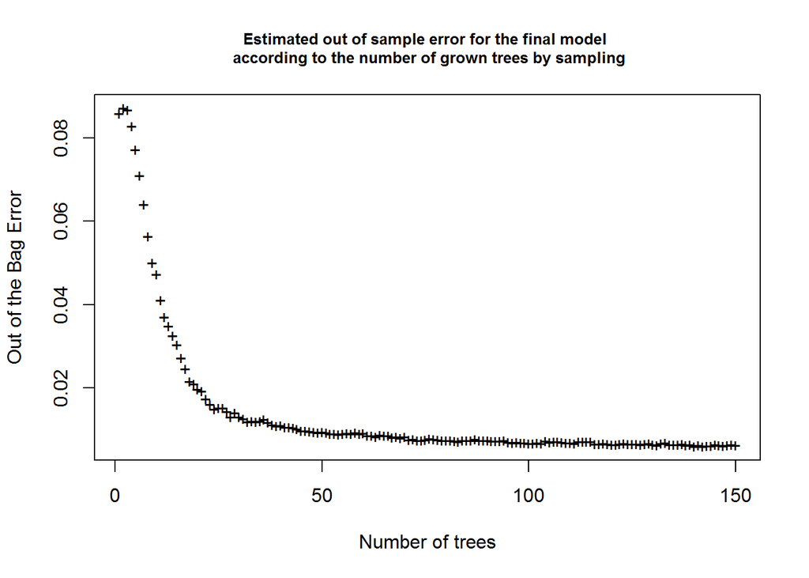

```r
model.rf <- randomForest(classe~., data=train, mtry=mtry, ntree=ntree)
#Diagnostics: Do we need more than 150 trees by forest to correctly assess the OOB (Out Of the Bag) error, or can we decrease this number to increase the training speed?
plot(1:ntree, model.rf$err.rate[,1], pch="+",main="Estimated out of sample error for the final model \n according to the number of grown trees by sampling", xlab="Number of trees", ylab="Out of the Bag Error", cex.main=0.8)
```

```r
#OOB error decrease as the number of grown trees increases. ntree <- 150 appears enough to reach plateau.
data.frame(MeanDecreaseGini=model.rf$importance[order(model.rf$importance, decreasing = T),]) #importance of variables by decreasing order
```

```
##                      MeanDecreaseGini
## roll_belt                   832.56991
## yaw_belt                    635.77369
## magnet_dumbbell_z           536.58753
## pitch_forearm               534.69213
## magnet_dumbbell_y           471.36352
## pitch_belt                  468.25367
## roll_forearm                437.13578
## magnet_dumbbell_x           342.70437
## magnet_belt_z               303.96495
## accel_dumbbell_y            295.50531
## accel_belt_z                285.43886
## magnet_belt_y               280.50815
## roll_dumbbell               279.64406
## accel_forearm_x             233.17656
## accel_dumbbell_z            226.80643
## roll_arm                    225.09851
## gyros_belt_z                217.33139
## magnet_forearm_z            195.19644
## total_accel_dumbbell        190.14488
## gyros_dumbbell_y            189.55155
## magnet_arm_x                183.66414
## accel_dumbbell_x            181.73882
## magnet_belt_x               175.78382
## magnet_arm_y                173.12489
## accel_arm_x                 171.27117
## accel_forearm_z             163.88290
## total_accel_belt            161.77810
## magnet_forearm_x            160.84449
## yaw_arm                     157.49683
## yaw_dumbbell                154.58062
## magnet_forearm_y            149.25885
## magnet_arm_z                123.81276
## pitch_dumbbell              121.66599
## yaw_forearm                 120.86121
## pitch_arm                   119.09848
## accel_arm_y                 113.82971
## accel_forearm_y             102.26729
## gyros_arm_y                  98.50973
## gyros_arm_x                  97.37910
## gyros_dumbbell_x             89.32037
## accel_belt_y                 89.01444
## gyros_forearm_y              87.38210
## accel_arm_z                  87.13086
## gyros_belt_y                 86.99643
## accel_belt_x                 85.41870
## total_accel_forearm          75.97646
## gyros_belt_x                 68.92967
## total_accel_arm              65.56818
## gyros_forearm_z              62.17794
## gyros_dumbbell_z             56.31620
## gyros_forearm_x              50.55529
## gyros_arm_z                  44.22262
```

```r
min(model.rf$oob.times); max(model.rf$oob.times)#range of the number of times each sample was held "out of the bag" to build individual trees from bootstrap samplings
```

```
## [1] 34
```

```
## [1] 77
```

```r
paste(round(model.rf$err.rate[ntree, 1]*100,2),"%", sep=" ")# Overall % out of sample error estimated over OOB from the ntree bootstrap samplings.
```

```
## [1] "0.63 %"
```

5. *Out of sample error calculation through the testing set*

```r
confusionMatrix(test$classe, predict(model.rf, test))
```

```
## Confusion Matrix and Statistics
##
##           Reference
## Prediction    A    B    C    D    E
##          A 1673    1    0    0    0
##          B    6 1133    0    0    0
##          C    0    3 1021    2    0
##          D    0    0   10  953    1
##          E    0    0    3    1 1078
##
## Overall Statistics
##
##                Accuracy : 0.9954
##                  95% CI : (0.9933, 0.997)
##     No Information Rate : 0.2853
##     P-Value [Acc > NIR] : < 2.2e-16
##
##                   Kappa : 0.9942
##  Mcnemar's Test P-Value : NA
##
## Statistics by Class:
##
##                      Class: A Class: B Class: C Class: D Class: E
## Sensitivity            0.9964   0.9965   0.9874   0.9969   0.9991
## Specificity            0.9998   0.9987   0.9990   0.9978   0.9992
## Pos Pred Value         0.9994   0.9947   0.9951   0.9886   0.9963
## Neg Pred Value         0.9986   0.9992   0.9973   0.9994   0.9998
## Prevalence             0.2853   0.1932   0.1757   0.1624   0.1833
## Detection Rate         0.2843   0.1925   0.1735   0.1619   0.1832
## Detection Prevalence   0.2845   0.1935   0.1743   0.1638   0.1839
## Balanced Accuracy      0.9981   0.9976   0.9932   0.9973   0.9991
```

From the test set, the accuracy and Kappa values are about 99.5%, what implies an out of sample error about 0.5%.